# Download plant species data by hexagon to make a 3D hex map

Eukaryota

Plantae

Maps

Making plots eye-catching can be useful for science communication. Here, we show how to make 3D plots in R with the `rayshader` package by visualising the number of species identified from ALA observations since 2020

Dax Kellie  
2022-05-23

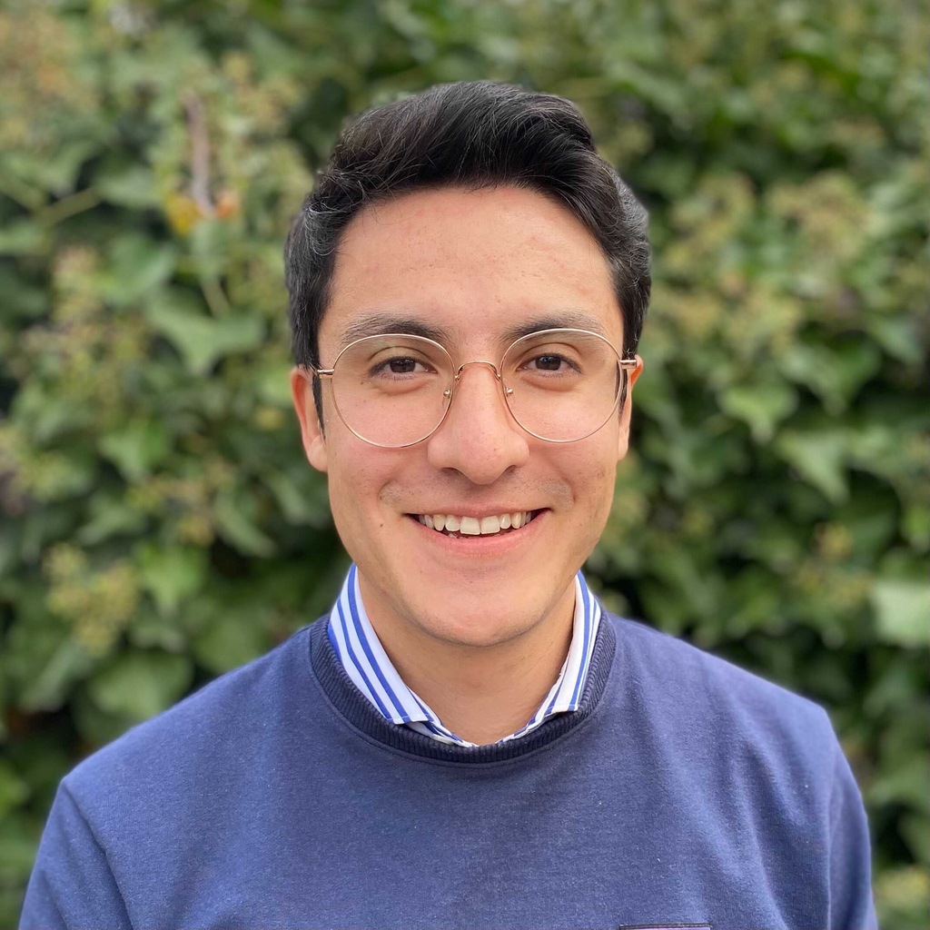

#### Author:

[Dax Kellie](https://labs.ala.org.au/people/Kellie_Dax/index.html)

#### Date:

23 May, 2022

Grabbing people’s attention in a content-filled world can be difficult. 3D maps can be particularly eye-catching, and thanks to the [`rayshader` package](https://www.rayshader.com/) it has become relatively simple to make a beautiful 3D plot from a plot made with `ggplot2`.

In this post, we’ll make a 3D hex map of the number of plant species identified from ALA observations since 2020. This map builds on a [previous hex map post](https://labs.ala.org.au/posts/2021-04-14_hex-maps-for-species-occurrence-data/), but this time we will use a more unique “grid-to-data” method to download our data, where instead of plotting hexagons over our map *after* extracting data, we’ll create a grid of hexagons that map to Australia *before* extracting any data and query the ALA for data for *each* hexagon. This method is cool because it saves a lot of work wrangling your data to fit your plot later on.

# Make a hexagon map

First let’s download the necessary packages

```r
# packages
library(galah)      # To download species data
library(rayshader)  # For 3d rendering
library(tidyverse)  # Data wrangling
library(here)       # Safe paths
library(sf)         # Spatial features
library(ozmaps)     # For map of oz
```

Now let’s get a map of Australia from the [`ozmaps` package](https://github.com/mdsumner/ozmaps)

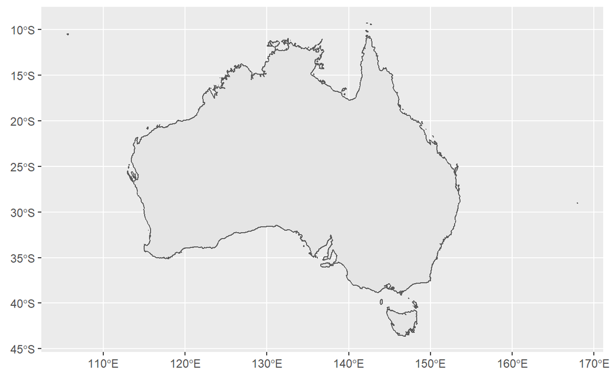

```r
# get a map and project to WGS84
oz_wgs84 <- ozmap_data(data = "country") |>
  st_transform(crs = st_crs("WGS84"))

## check map
ggplot(oz_wgs84) + geom_sf()
```

Next let’s create our grid of hexagons and do some tidying to make sure the hexagons are only over the land

```r
# create grid
oz_grid <- st_make_grid(oz_wgs84,
                        what = "polygons",
                        cellsize = 1.0,
                        square = FALSE,
                        flat_topped = TRUE)

# subset to grid cells that are within land
keep_hexes <- st_intersects(oz_grid, oz_wgs84)
keep_hexes <- as.data.frame(keep_hexes)$row.id
oz_grid <- oz_grid[keep_hexes]
```

If we plot our new `oz_grid` over our map, we can see how the hexagons fill our map of Australia

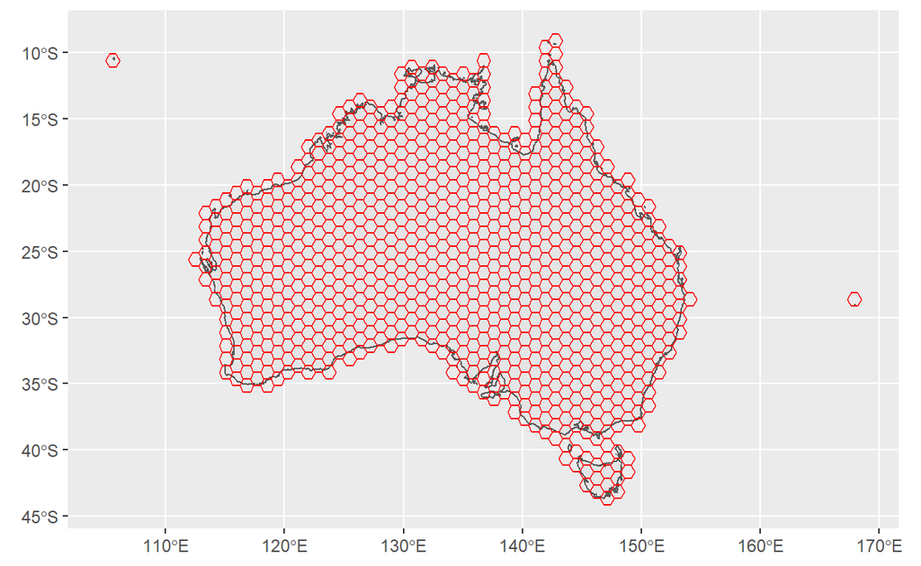

```r
## check
ggplot() +
  geom_sf(data = oz_wgs84) +
  geom_sf(data = oz_grid, fill = NA, color = "red")
```

# Download species data

Now that we have our grid of hexagons, we can download data from the ALA using the [`galah` package](https://atlasoflivingaustralia.github.io/galah/index.html). Rather than downloading all data on the number of species identified since 2020 and then plotting the data as hexagons, we will make a function that sends individual queries to return the number of species identified within *each hexagon*.

Our function `get_counts()` works in 3 parts:

```r
get_counts <- function(hexagon){

    # convert to wkt
    wkt_string <- st_as_text(oz_grid[[hexagon]]) %>%
      sub(")))", "))", .) %>%
      sub("POLYGON ", "POLYGON", .)

    # get counts
    result <- galah_call() |>
      galah_geolocate(wkt_string) |>
      galah_identify("plantae", "chlorophyta") |>
      galah_filter(profile = "ALA",
                   decimalLongitude > 110,
                   year >= 2020) |>
      atlas_counts(type = "species", # get species counts
                   limit = NULL)

    # light formatting to catch errors
    if(is.null(result)){
      tibble(count = NA, id = hexagon)
    }else{
      result$id <- hexagon
      result
    }
  }
```

We can use `purrr::map()` to run this function recursively for each hexagon. Then we can bind the separate lists into one data.frame with `purrr::map_dfr()`. As `oz_grid` is a spatial object containing `POLYGON`s (which R treats slightly differently to a `data.frame`), we have to use `seq_along(oz_grid)` to enable us to run the function for each line, which corresponds to each `POLYGON`.

**IMPORTANT NOTE:** This function will send **lots** of queries all at once to the ALA, so it is best to use restraint on how many times you run it because it can take a long time and, if run many times in a row, can make it take even longer.

```r
# download number of species for each polygon
counts_list <- map(seq_along(oz_grid), get_counts)

# bind lists to data frame
counts_df <- map_dfr(counts_list, rbind)
```

`counts_df` now contains a single count of species for each hexagon, indicated by a unique `id`

```r
head(counts_df, 10L)
```

```
# A tibble: 10 x 2
   count    id
   <dbl> <int>
 1   396     1
 2   303     2
 3   457     3
 4   178     4
 5  1025     5
 6   442     6
 7   507     7
 8   438     8
 9   592     9
10     5    10
```

Now let’s merge our species counts in `counts_df` to our `oz_grid` hexagons so we can plot them. To do so, we’ll convert `oz_grid` to a tibble called `oz_df`, add a blank `count` column, and fill that column with the species counts in `counts_df` for each hexagon by `id`.

```r
# convert to tibble, attach counts
oz_df <- st_as_sf(oz_grid)
oz_df$count <- NA
oz_df$count[counts_df$id] <- counts_df$count
```

Let’s see the final result by checking the hexagons with highest species counts

```r
# See top hexagons
oz_df %>%
  arrange(desc(count)) %>%
  head(10L)
```

```
Simple feature collection with 10 features and 1 field
Geometry type: POLYGON
Dimension:     XY
Bounding box:  xmin: 137.8823 ymin: -38.63203 xmax: 153.7594 ymax: -26.63203
Geodetic CRS:  WGS 84
   count                              x
1   2543 POLYGON ((150.0066 -33.6320...
2   2144 POLYGON ((150.8726 -34.1320...
3   2073 POLYGON ((144.8105 -37.6320...
4   2005 POLYGON ((150.0066 -34.6320...
5   1959 POLYGON ((152.6047 -27.1320...
6   1949 POLYGON ((152.6047 -28.1320...
7   1804 POLYGON ((150.8726 -33.1320...
8   1616 POLYGON ((151.7387 -27.6320...
9   1604 POLYGON ((137.8823 -34.6320...
10  1577 POLYGON ((143.9444 -38.1320...
```

# Plot number of species

The first step to making our 3D map is to make a 2D map with `ggplot2`. I have set the `fill` of our map to use `oz_df`’s `count` column and log transformed it to make our final scale easier to read. The `scale_fill_distiller()` function has a nice “Greens” palette to make our plant species data look extra planty, and I have added custom limits and labels to make sure the scale is understandable.

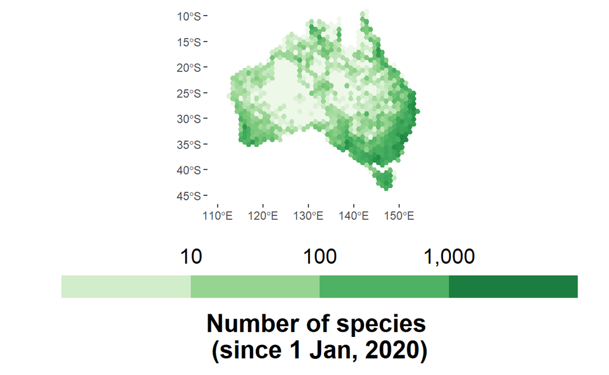

```r
hex_map <- ggplot() +
  geom_sf(
    data = oz_df,
    mapping = aes(fill = log10(count + 1)), # log10 + 1 transformed
    alpha = 1,
    color = NA) +
  scale_fill_distiller(name = "Number of species \n(since 1 Jan, 2020)",
                       type = "seq",
                       direction = 1,
                       limits = c(0,4),
                       labels = c("10", "100", "1,000"),
                       palette = "Greens",
                       # edit legend to be horizontal-bottom
                       guide = guide_colorsteps(direction = "horizontal",
                                                label.position = "top",
                                                title.position = "bottom",
                                                title.hjust = 0.5)
                       ) +
  # add map
  geom_sf(data = oz_wgs84,
          color = NA,
          fill = NA)  +
  # crop map
  coord_sf(xlim = c(110, 155),
           ylim = c(-45, -10)) +
  # Adjust text and make aesthetic more minimal
  theme(title = element_text(face = "bold"),
        legend.title = element_text(size = 19),
        legend.position = "bottom",
        legend.key.width = unit(28, 'mm'),
        legend.text = element_text(size = 16),
        plot.background = element_rect(fill = 'white', colour = 'white'),
        panel.background = element_rect(fill = 'white', colour = 'white'),
        axis.title = element_blank()
        )

hex_map
```

# Render in 3D

It’s time to get 3-Dimensional! Using `rayshader::plot_gg()`, we can render a nice 3d version of our plot[^1]

[figure not shown]

```r
# Render 3d plot
plot_gg(hex_map,
        width = 9,
        height = 8,
        scale = 300, # adjust height of 3D transformation
        windowsize = c(1200, 960), # adjust window of rendered plot
        fov = 75,    # adjust size/strength of blur around outer edges
        zoom = 0.37,
        theta = 320, # adjust left-right rotation of view
        phi = 33)    # adjust height of view
```

Looks great! Finally, we can save our plot using `render_snapshot()`

```r
# save
Sys.sleep(0.2)
render_snapshot(here("folder", "subfolder", "3d-map.png"))
```

In this case, a 3D map makes the areas with many and few species very noticeable, which is a useful message to communicate.

However, in general, one should be careful about using 3D plots without first considering the main messages they want people to take away from their data, and whether a 3D figure communicates this better than a 2D alternative. People aren’t as good at quickly interpreting differences in height, shape or location in 3D plots compared to 2D plots. One reason for this weakness is that most 3D plots can only be viewed from a single angle. Depending on what angle the view point of the plot is set to, the literal differences in heights or locations between shapes might change, even if their actual differences in the data they represent don’t change. Looking at a 3D map from above, in the middle, or below changes how the shapes appear, and sometimes they may not accurately represent the *true* differences between things you want to compare in your plot. This quirk of 3D plots makes it easier for people to misinterpret your plot and, as a result, take away the wrong message from the data (this idea is known as the **principle of proportional ink** ([Tufte, 1983](https://www.edwardtufte.com/tufte/books_vdqi)). Carl Bergstrom has written an excellent explanation of why this principle matters in data visualisation)

Even so, 3D plots can be a beautiful way to see the number of plant species identified in the ALA since 2020. Even cooler, querying species data from the ALA for each hexagon in our map with `galah` can be an efficient way to download data and reduce data wrangling work later on!

[^1]: If you get a weird error related to the `scales` package, updating to the latest version should fix it: https://github.com/tylermorganwall/rayshader/issues/181#:~:text=Update%20to%20the,install.packages(%27rayshader%27)